# A N I M E

## EDA: Exploratory Data Analysis

> “The goal of EDA is to perform an initial exploration of attributes/variables across entities/observations.” Hector Corrado Bravo

#### Quick Overview with a Scatterplot

Ok, let’s get to it! First, we have to import the libraries tibble and ggplot2 for working with dataframes and plotting them.

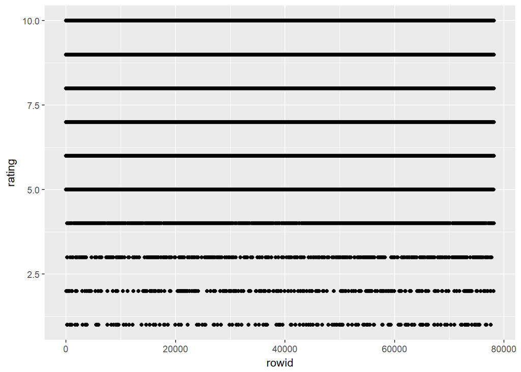

```r
library(tibble)
library(ggplot2)
ratings %>%
  sample_frac(.01) %>%
  rowid_to_column() %>%
  ggplot(aes(x=rowid, y=rating)) +
    geom_point()
```

Now we have a simple scatterplot. Confused? Don’t worry, sensei’s got your back. Here are the main points:

- **sample_frac** gets you a random sample of the data - there are just too many [otakus](https://www.merriam-webster.com/words-at-play/what-does-otaku-mean-in-japanese) to sort through, so we just take .01 or 1% of the ratings.
- **ggplot** creates the actual plot and **aes** creates the A E S T H E T I C S (what it looks like).
- **geom_point()** creates the points that our scatterplot is scattered with.

Yeah, there are way too many ratings, so much for a scatterplot - the dots have converged; it’s basically just a bunch of lines since there are way too many ratings squished together.

However, notice that at the bottom of the graph, the plot shows a bit more *“scatter”*. Basically, this means that there is less data of people giving lower scores.

This seems about right, I don’t really rate things low either. Perhaps the reason for this is if one were to have rated an anime low, they would have just dropped the show earlier on or not given it a rating at all.

Let us picture the distribution a bit more clear.

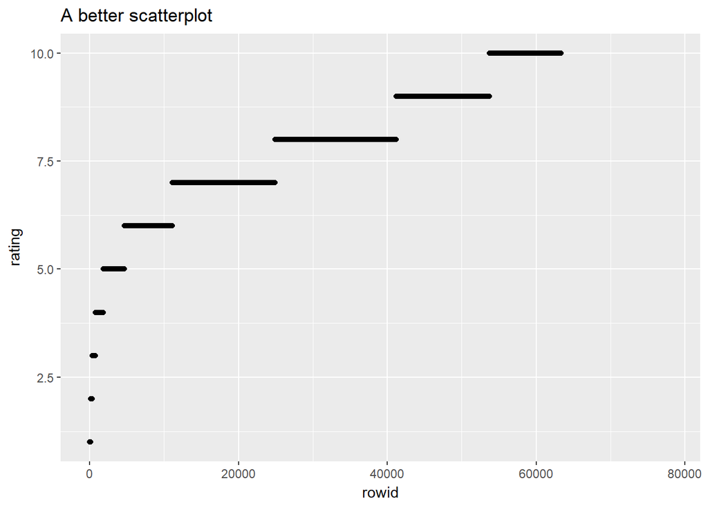

```r
ratings %>%
  sample_frac(.01) %>%
  arrange(rating) %>%
  rowid_to_column() %>%
  ggplot(aes(x=rowid, y=rating)) +
    geom_point() +
    ggtitle("A better scatterplot")
```

The **arrange** function allows us to sort data, in this case by ratings.

Hmmm…seems in line with what we explained to ourselves above. There are very few low ratings and much more high ratings. Just take a look at how *thicc* the lines are with ratings around 7 to 9.

#### Summary Statistics

We **filter** out the data that is **NA** to remove all the useless data that significantly impacts the speed of the code.

```r
ratings <- ratings %>%
   filter(!is.na(rating))
ratings %>%
  summarize(min_rating = min(rating),
            max_rating = max(rating),
            median_rating=median(rating),
            mean_rating=mean(rating))
```

```
## # A tibble: 1 x 4
##   min_rating max_rating median_rating mean_rating
##        <dbl>      <dbl>         <int>       <dbl>
## 1       1.00       10.0             8        7.81
```

#### Central Tendency

We have the summary statistics; now we shall visualize the median of this on a histogram in order to better picture the distribution of ratings. The median is the 50th percentile. Half of the data is below it, and half is above it. Let’s take a look at where this falls (median in vertical line):

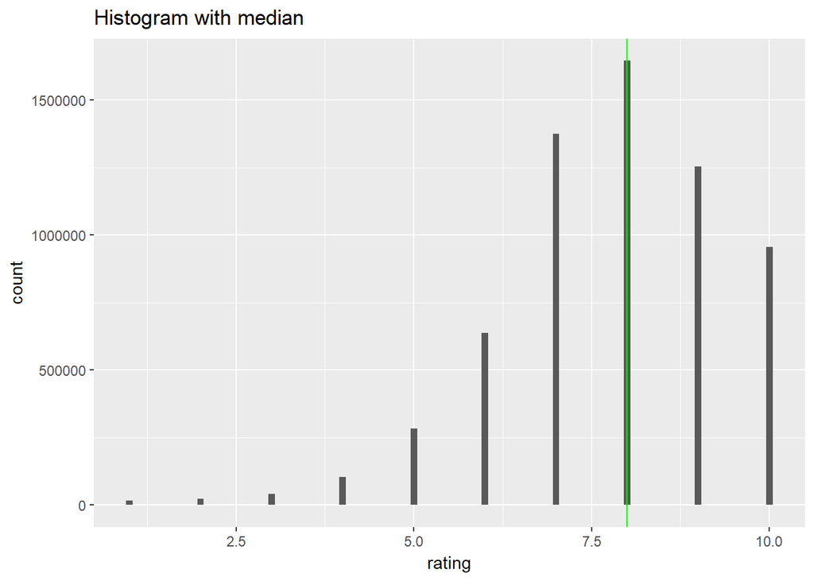

```r
ratings %>%
   filter(!is.na(rating)) %>%
    ggplot(aes(x=rating)) +
    geom_histogram(bins=100)+
      ggtitle("Histogram with median") +
      geom_vline(aes(xintercept=median(rating)), color="green")
```